# Homework Week 7 Day 1

```r
library(dplyr)
library(lubridate)
library(tidyverse)
library(tsibble)
library(tsibbledata)
library(feasts)
library(slider)

date1 <- ymd_hms("2017-04-22 22:01:18")
date2 <- ymd_hms("2001-11-07 10:09:56")
```

```r
date1
```

```
[1] "2017-04-22 22:01:18 UTC"
```

1. Extract the different components (year, month, mday, yday, wday) from the variable date1. Add the labels to the month and do not abbreviate the month labels.

```r
year(date1)
```

```
[1] 2017
```

```r
month(date1, label = TRUE)
```

```
[1] Apr
Levels: Jan < Feb < Mar < Apr < May < Jun < Jul < Aug < Sep < Oct < Nov < Dec
```

```r
mday(date1)
```

```
[1] 22
```

```r
yday(date1)
```

```
[1] 112
```

```r
wday(date1)
```

```
[1] 7
```

2. Add 14 days to your date1 variable and store it in a variable called next_fortnight. Take away 10 years from your date2 variable, and store it in previous_decade.

```r
next_fortnight <- date1 + days(14)
next_fortnight
```

```
[1] "2017-05-06 22:01:18 UTC"
```

```r
previous_dacade <- date2 - years(10)
previous_dacade
```

```
[1] "1991-11-07 10:09:56 UTC"
```

3. Create a variable called this_year which contains today’s date. Then create an interval object which uses this_year and the previous_decade variable you made above. Store it in interval_years. Hint: you’ll need to use lubridate::interval in order to get the right function, as tsibble has one too

```r
this_year <- today()

interval_years <- lubridate::interval(this_year, previous_dacade)

interval_years
```

```
[1] 2020-11-30 UTC--1991-11-07 10:09:56 UTC
```

4. Change the time zone of both your date variables to “America/New_York”, and call them nyc_date1 and nyc_date2.

```r
nyc_date1 <- with_tz(date1, tz = "America/New_York")

nyc_date2 <- with_tz(date2, tz = "America/New_York")

nyc_date1
```

```
[1] "2017-04-22 18:01:18 EDT"
```

```r
nyc_date2
```

```
[1] "2001-11-07 05:09:56 EST"
```

5. Use the flights data from the nycflights13 dataset. Make a date-time column called departure_date from the year, month, day, hour, and minute variables in the flights tibble.

```r
flights %>%
  mutate(departure_date = make_datetime(year, month, day, hour, minute))
```

| year | month | day | dep_time | sched_dep_time | dep_delay | arr_time | sched_arr_time | arr_delay | carrier | flight | tailnum | origin | dest | air_time | distance | hour | minute | time_hour | departure_date |
| --- | --- | --- | --- | --- | --- | --- | --- | --- | --- | --- | --- | --- | --- | --- | --- | --- | --- | --- | --- |
| 2013 | 1 | 1 | 517 | 515 | 2 | 830 | 819 | 11 | UA | 1545 | N14228 | EWR | IAH | 227 | 1400 | 5 | 15 | 2013-01-01 05:00:00 | 2013-01-01 05:15:00 |
| 2013 | 1 | 1 | 533 | 529 | 4 | 850 | 830 | 20 | UA | 1714 | N24211 | LGA | IAH | 227 | 1416 | 5 | 29 | 2013-01-01 05:00:00 | 2013-01-01 05:29:00 |
| 2013 | 1 | 1 | 542 | 540 | 2 | 923 | 850 | 33 | AA | 1141 | N619AA | JFK | MIA | 160 | 1089 | 5 | 40 | 2013-01-01 05:00:00 | 2013-01-01 05:40:00 |
| 2013 | 1 | 1 | 544 | 545 | -1 | 1004 | 1022 | -18 | B6 | 725 | N804JB | JFK | BQN | 183 | 1576 | 5 | 45 | 2013-01-01 05:00:00 | 2013-01-01 05:45:00 |
| 2013 | 1 | 1 | 554 | 600 | -6 | 812 | 837 | -25 | DL | 461 | N668DN | LGA | ATL | 116 | 762 | 6 | 0 | 2013-01-01 06:00:00 | 2013-01-01 06:00:00 |
| 2013 | 1 | 1 | 554 | 558 | -4 | 740 | 728 | 12 | UA | 1696 | N39463 | EWR | ORD | 150 | 719 | 5 | 58 | 2013-01-01 05:00:00 | 2013-01-01 05:58:00 |
| 2013 | 1 | 1 | 555 | 600 | -5 | 913 | 854 | 19 | B6 | 507 | N516JB | EWR | FLL | 158 | 1065 | 6 | 0 | 2013-01-01 06:00:00 | 2013-01-01 06:00:00 |
| 2013 | 1 | 1 | 557 | 600 | -3 | 709 | 723 | -14 | EV | 5708 | N829AS | LGA | IAD | 53 | 229 | 6 | 0 | 2013-01-01 06:00:00 | 2013-01-01 06:00:00 |
| 2013 | 1 | 1 | 557 | 600 | -3 | 838 | 846 | -8 | B6 | 79 | N593JB | JFK | MCO | 140 | 944 | 6 | 0 | 2013-01-01 06:00:00 | 2013-01-01 06:00:00 |
| 2013 | 1 | 1 | 558 | 600 | -2 | 753 | 745 | 8 | AA | 301 | N3ALAA | LGA | ORD | 138 | 733 | 6 | 0 | 2013-01-01 06:00:00 | 2013-01-01 06:00:00 |

[output cut: 990 more lines]

6. Start with the weather data from the nycflights13 package. Select all the variables related to temperature, humidity, and precipitation, and pick out the key and index variables. Have a look at your data, and write a small description of the time series you observe.

Here we can see that our data is collected in hourly format, with observations occuring every day.

```r
selected_weather <- weather %>%
  select(time_hour, origin, temp, humid, precip)

selected_weather
```

[output not shown]

The time series is every hour. the index variable: time_hour, and the key variable: origin

7. Change the weather data into a tsibble. Hint, look up in the notes where we suggest using as_tsibble function. You’ll need to define an index and key.

In order to create a time series tibble, remember you need to provide an index and a key. In our case, time_hour is the only column involving a date/date-time, and so this would be our index. A tsibble also requires a key, which defines individual observations that are tracked over time. In this example, the origin variable is the identifier, and therefore is our key. It is important to note that the duo of the index and key uniquely identifies each observation in a valid tsibble.

```r
weather_tsbl <- weather %>%
  as_tsibble(index = time_hour, key = origin)

weather_tsbl
```

| origin | year | month | day | hour | temp | dewp | humid | wind_dir | wind_speed | wind_gust | precip | pressure | visib | time_hour |
| --- | --- | --- | --- | --- | --- | --- | --- | --- | --- | --- | --- | --- | --- | --- |
| EWR | 2013 | 1 | 1 | 1 | 39.02 | 26.06 | 59.37 | 270 | 10.35702 | NA | 0.00 | 1012.0 | 10.00 | 2013-01-01 01:00:00 |
| EWR | 2013 | 1 | 1 | 2 | 39.02 | 26.96 | 61.63 | 250 | 8.05546 | NA | 0.00 | 1012.3 | 10.00 | 2013-01-01 02:00:00 |
| EWR | 2013 | 1 | 1 | 3 | 39.02 | 28.04 | 64.43 | 240 | 11.50780 | NA | 0.00 | 1012.5 | 10.00 | 2013-01-01 03:00:00 |
| EWR | 2013 | 1 | 1 | 4 | 39.92 | 28.04 | 62.21 | 250 | 12.65858 | NA | 0.00 | 1012.2 | 10.00 | 2013-01-01 04:00:00 |
| EWR | 2013 | 1 | 1 | 5 | 39.02 | 28.04 | 64.43 | 260 | 12.65858 | NA | 0.00 | 1011.9 | 10.00 | 2013-01-01 05:00:00 |
| EWR | 2013 | 1 | 1 | 6 | 37.94 | 28.04 | 67.21 | 240 | 11.50780 | NA | 0.00 | 1012.4 | 10.00 | 2013-01-01 06:00:00 |
| EWR | 2013 | 1 | 1 | 7 | 39.02 | 28.04 | 64.43 | 240 | 14.96014 | NA | 0.00 | 1012.2 | 10.00 | 2013-01-01 07:00:00 |
| EWR | 2013 | 1 | 1 | 8 | 39.92 | 28.04 | 62.21 | 250 | 10.35702 | NA | 0.00 | 1012.2 | 10.00 | 2013-01-01 08:00:00 |
| EWR | 2013 | 1 | 1 | 9 | 39.92 | 28.04 | 62.21 | 260 | 14.96014 | NA | 0.00 | 1012.7 | 10.00 | 2013-01-01 09:00:00 |
| EWR | 2013 | 1 | 1 | 10 | 41.00 | 28.04 | 59.65 | 260 | 13.80936 | NA | 0.00 | 1012.4 | 10.00 | 2013-01-01 10:00:00 |

[output cut: 990 more lines]

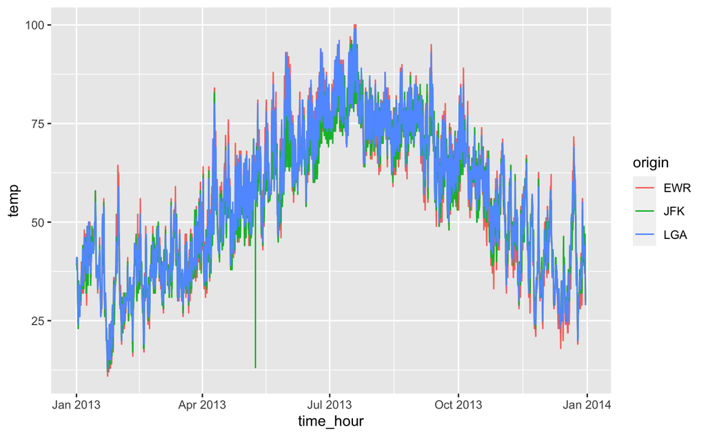

```r
weather_tsbl1 <- weather_tsbl %>%
  mutate(year = year(time_hour),
         month = month(time_hour))


# Basic line plot with points : all data
ggplot(data = weather_tsbl1, aes(x = time_hour, y = temp, group = origin)) + geom_line(aes(color=origin))
```

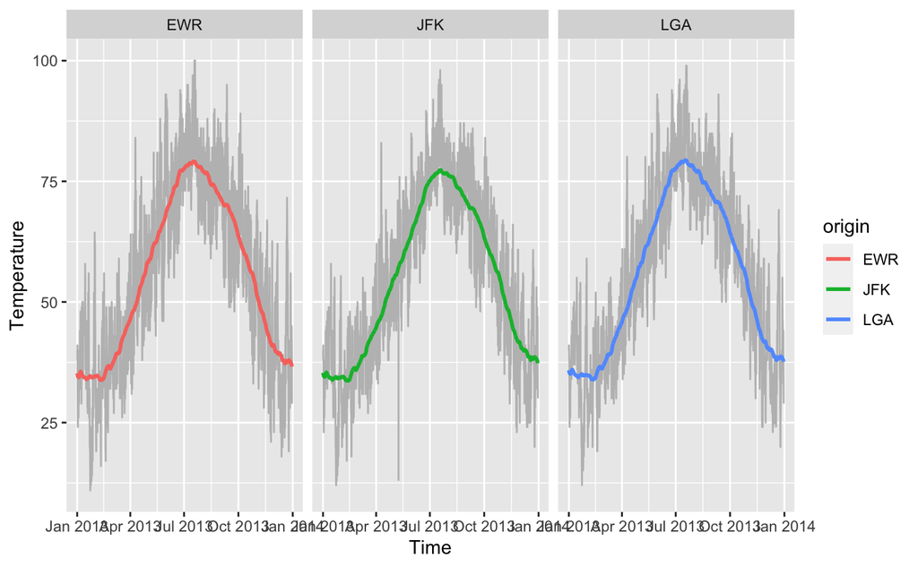

```r
# calculate a rolling window
weather_rolling <- weather_tsbl %>%
  group_by_key(origin) %>%
  mutate(temp_ma = slide_dbl(temp, ~ mean(., na.rm = TRUE), .after = 600, .before = 600 ))

# plot the data
ggplot(weather_rolling) +
  geom_line(aes(x = time_hour, y = temp, group = origin), colour = "grey") +
  geom_line(aes(x = time_hour, y = temp_ma, colour = origin), size = 1) +
  facet_wrap(~ origin) +
  ylab("Temperature") +
  xlab("Time")
```

10. Downsample your data so that you plot daily temperature data for each airport, instead of hourly data.

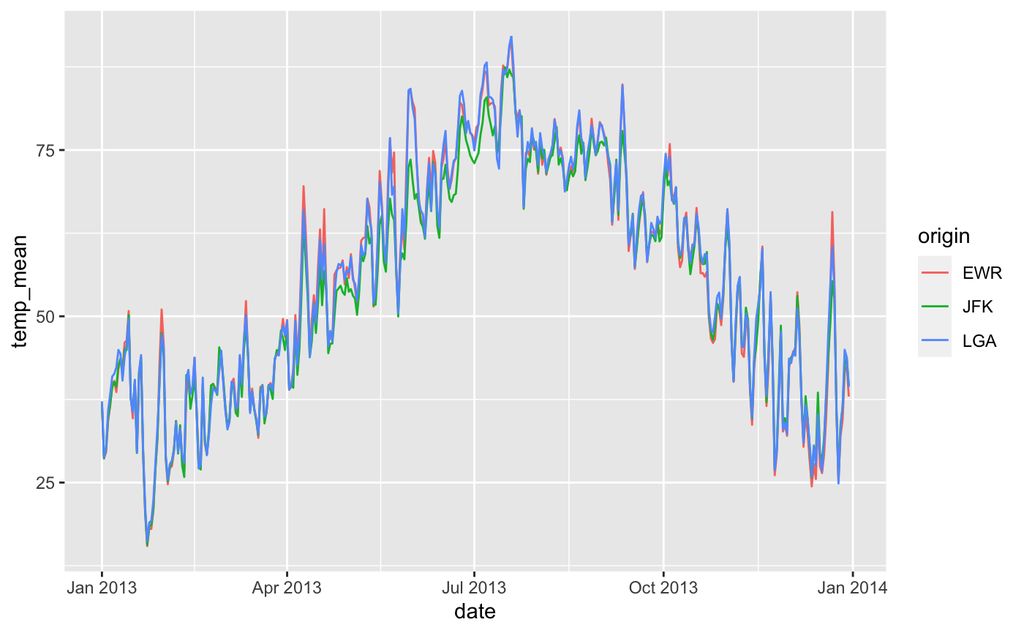

```r
# aggregate by date
weather_date <- weather_tsbl %>%
  group_by_key(origin) %>%
  index_by(date = as_date(time_hour)) %>%
  summarise(temp_mean = mean(temp, na.rm = TRUE))

# make a plot
ggplot(data = weather_date, aes(x = date, y = temp_mean, group = origin)) +
  geom_line(aes(color=origin))
```